# Teaching hydrology with airGRteaching

# Model calibration

## Manual calibration

In the **airGRteaching** GUI, it is possible to test different parameter sets of the GR rainfall-runoff models and to estimate the performance of each tested parameter set in order to perform a manual calibration. A classical way to do so through the **airGRteaching** GUI is to pick an objective function in the table showing the criteria values on the right, to activate the “Show previous simulations (Qold)” button, and to modify parameter values little by little until the simulation and the criterion are satisfactory.

Note that the manual calibration of model parameters is facilitated using the **airGRteaching** graphical user interface launched by the `ShinyGR()` function.

You can embed the following code in a loop (except the data processing step using `PrepGR()`). At each iteration you test a new parameter set and compute the corresponding criterion. This way you can find the “best” parameter set.

```r
# Data processing for GR4J (with Q for calibration)
prep <- PrepGR(DatesR     = ts_obs$Date,
               Precip     = ts_obs$Ptot,
               PotEvap    = ts_obs$Evap,
               Qobs       = ts_obs$Qmmd,
               HydroModel = "GR4J",
               CemaNeige  = FALSE)

# Parameter set to test
i_param_gr4j <- c(X1 = 350, X2 = 0, X3 = 90, X4 = 1.4)

# Rainfall-runoff simulation on the calibration period
i_sim_manu <- SimGR(PrepGR  = prep,
                    Param   = param_gr4j,
                    WupPer  = c("1999-01-01", "2000-12-31"),
                    SimPer  = c("2001-01-01", "2010-12-31"),
                    EffCrit = "NSE",
                    verbose = TRUE)
```

```
## Crit. NSE[Q] = 0.6295
```

```r
# Get the criterion value
GetCrit(i_sim_manu)
```

```
##    NSE[Q]
## 0.6294621
```

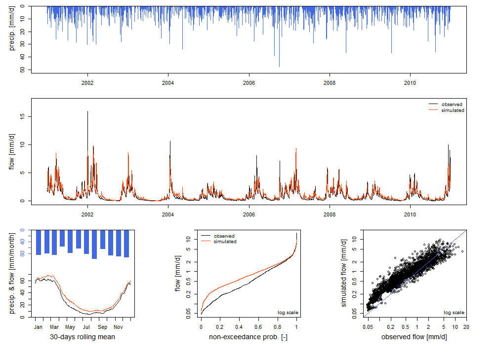

```r
# Graphical assessment of the calibration performance
plot(i_sim_manu)
```

## Automatic calibration

Automatic calibration of model parameters is also possible in **airGRteaching** using the procedure described by Michel (1991) and by considering one objective function such as NSE (Nash and Sutcliffe 1970) or KGE (Gupta et al. 2009). To do so, there are two options in airGRteaching:

1. clicking on the “Automatic calibration button” in the **airGRteaching** GUI;
2. using the simple **airGRteaching** command line functions (`PrepGR()` and `CalGR()`); see following commands.

```r
# Calibration using NSE score
cal_auto <- CalGR(PrepGR  = prep,
                  CalCrit = "NSE",
                  WupPer  = c("1999-01-01", "2000-12-31"),
                  CalPer  = c("2001-01-01", "2010-12-31"))
```

```
## Grid-Screening in progress (0% 20% 40% 60% 80% 100%)
##   Screening completed (81 runs)
##       Param =  247.151,   -2.376,   83.096,    2.384
##       Crit. NSE[Q]       = 0.7372
## Steepest-descent local search in progress
##   Calibration completed (27 iterations, 281 runs)
##       Param =  242.257,   -0.888,   63.434,    5.126
##       Crit. NSE[Q]       = 0.9095
```

```r
# Get parameter and criteria values at the end of the calibration step
GetParam(cal_auto)
```

```
## [1] 242.257207  -0.888106  63.434000   5.126126
```

```r
GetCrit(cal_auto)
```

```
##   NSE[Q]
## 0.909467
```

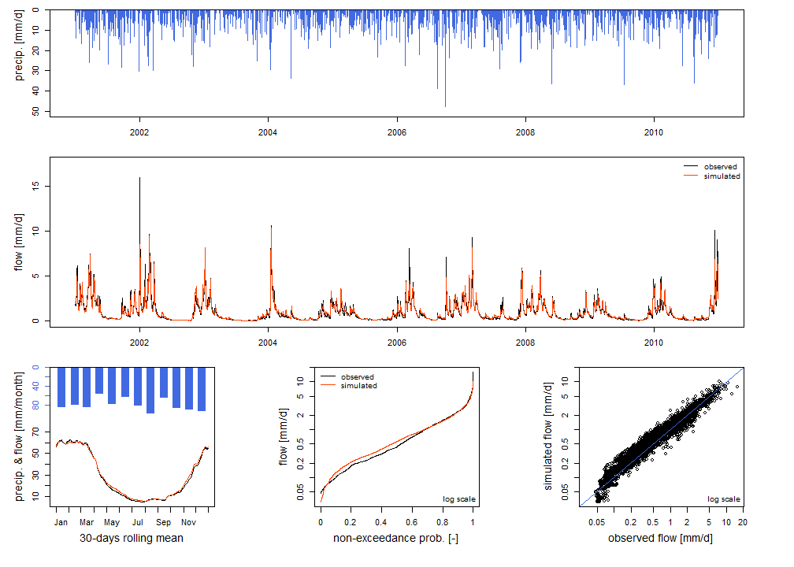

```r
# Graphical assessment of the calibration performance
plot(cal_auto)
```

## How to evaluate model calibration?

Different ways of evaluating the model calibration performance may be conceived using **airGRteaching**: evaluating criteria on the calibration period, looking at the graphical summary of the calibration performance (displaying using the `plot()` function), comparing simulated and observed streamflows temporal series, etc.

Analyzing simulated versus observed streamflow regimes is an informative indicator of model performance. The following commands and figure compare regimes on a mountainous catchment (located in the French Alps), while the streamflow simulation has been obtained with and without taking into account snow accumulation and melting. The regime comparison might be compelling for the students, hopefully leading them towards the guess of the need to use an additional snow accumulation and melting routine such as CemaNeige (Valéry et al. 2014), available using **airGRteaching**.

```r
# Catchment data loading
data("X031001001", package = "airGRdatasets")

# Observed daily time series
ts_obs <- X031001001$TS

# Catchment elevation distribution
hypso <- X031001001$Hypso

# Temporal subset
is_per <- ts_obs$Date >= as.POSIXct("1999-01-01", tz = "UTC") &
  ts_obs$Date <= as.POSIXct("2009-12-30", tz = "UTC")
ts_obs <- ts_obs[is_per, ]

# Data processing for GR4J (without snow module)
prep_snow_n <- PrepGR(DatesR     = ts_obs$Date,
                      Precip     = ts_obs$Ptot,
                      PotEvap    = ts_obs$Evap,
                      Qobs       = ts_obs$Qmmd,
                      HydroModel = "GR4J",
                      CemaNeige  = FALSE)

# Data processing for GR4J with snow module
prep_snow_y <- PrepGR(DatesR     = ts_obs$Date,
                      Precip     = ts_obs$Ptot,
                      PotEvap    = ts_obs$Evap,
                      Qobs       = ts_obs$Qmmd,
                      TempMean   = ts_obs$Temp,
                      ZInputs    = median(hypso),
                      HypsoData  = hypso,
                      NLayers    = 5,
                      HydroModel = "GR4J",
                      CemaNeige  = TRUE)

# Calibration using NSE score (without snow module)
cal_snow_n <- CalGR(PrepGR  = prep_snow_n,
                    CalCrit = "NSE",
                    WupPer  = c("1999-01-01", "2000-12-31"),
                    CalPer  = c("2001-01-01", "2009-12-30"),
                    verbose = TRUE)
```

```
## Grid-Screening in progress (0% 20% 40% 60% 80% 100%)
##   Screening completed (81 runs)
##       Param =  432.681,   -2.376,   83.096,    2.384
##       Crit. NSE[Q]       = -0.5939
## Steepest-descent local search in progress
##   Calibration completed (36 iterations, 357 runs)
##       Param = 1652.426,    1.369, 4359.009,    1.769
##       Crit. NSE[Q]       = 0.1700
```

```r
# Calibration using NSE score (with snow module)
cal_snow_y <- CalGR(PrepGR  = prep_snow_y,
                    CalCrit = "NSE",
                    WupPer  = c("1999-01-01", "2000-12-31"),
                    CalPer  = c("2001-01-01", "2009-12-30"),
                    verbose = TRUE)
```

```
## Grid-Screening in progress (0% 20% 40% 60% 80% 100%)
##   Screening completed (729 runs)
##       Param =  432.681,   -0.020,   83.096,    2.384,    0.043,    3.787
##       Crit. NSE[Q]       = 0.8072
## Steepest-descent local search in progress
##   Calibration completed (29 iterations, 1050 runs)
##       Param =  473.428,    0.984,  298.867,    1.388,    0.094,    3.982
##       Crit. NSE[Q]       = 0.9148
```

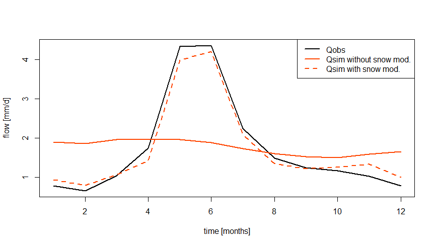

```r
# Combination of observed and simulated streamflow
tab_cal <- data.frame(Date        = cal_snow_n$OutputsModel$DatesR,
                      QOobs       = cal_snow_n$Qobs,
                      Qsim_snow_n = cal_snow_n$OutputsModel$Qsim,
                      Qsim_snow_y = cal_snow_y$OutputsModel$Qsim)

# Computation of regime streamflow
tab_cal_reg <- SeriesAggreg(tab_cal,
                            Format = "%m",
                            ConvertFun = rep("mean", ncol(tab_cal) - 1))

# Graphical comparison between simulated and observed streamflow regimes
col_snow <- c("black", rep("orangered", 2))
lty_snow <- c(1, 1:2)
matplot(y = tab_cal_reg[, grep("^Q", colnames(tab_cal))],
        xlab = "time [months]", ylab = "flow [mm/d]",
        type = "l", lty = lty_snow, lwd = 2, col = col_snow)
legend("topright",
       legend = c("Qobs", "Qsim without snow mod.", "Qsim with snow mod."),
       lty = lty_snow, lwd = 2, col = col_snow,
       bg = "white")
```

## Streamflow transformation for model calibration

Oudin et al. (2006) and many other authors showed the impact of using streamflow transformation during the model calibration. Using **airGRteaching**, it is possible to apply different streamflow transformations during the model parameter calibration. The following commands and figure compare the simulations performed considering GR4J parameter sets obtained after a calibration on (i) NSE calculated on natural streamflows (noted $NSE_Q$ hereafter), (ii) NSE calculated on square root transformed streamflows (noted $NSE_{\sqrt{Q}}$ hereafter) and (iii) NSE calculated on logarithmic transformed streamflows (noted $NSE_{\log{Q}}$ hereafter), emphazing performance on high, mean and low flows, respectively.

```r
# Catchment data loading
data("B222001001", package = "airGRdatasets")
ts_obs <- B222001001$TS

# Data processing for GR4J (with Q for calibration)
prep <- PrepGR(DatesR     = ts_obs$Date,
               Precip     = ts_obs$Ptot,
               PotEvap    = ts_obs$Evap,
               Qobs       = ts_obs$Qmmd,
               HydroModel = "GR4J",
               CemaNeige  = FALSE)

# Calibration using NSE score on raw Q
cal_raw <- CalGR(PrepGR  = prep,
                 CalCrit = "NSE",
                 transfo = "",
                 WupPer  = c("1999-01-01", "2001-12-31"),
                 CalPer  = c("2002-01-01", "2016-12-31"))
```

```
## Grid-Screening in progress (0% 20% 40% 60% 80% 100%)
##   Screening completed (81 runs)
##       Param =  432.681,   -0.020,   83.096,    2.384
##       Crit. NSE[Q]       = 0.7414
## Steepest-descent local search in progress
##   Calibration completed (27 iterations, 281 runs)
##       Param =  237.460,   -0.746,   64.072,    5.165
##       Crit. NSE[Q]       = 0.9063
```

```r
# Calibration using NSE score on sqrt(Q)
cal_sqrt <- CalGR(PrepGR  = prep,
                  CalCrit = "NSE",
                  transfo = "sqrt",
                  WupPer  = c("1999-01-01", "2001-12-31"),
                  CalPer  = c("2002-01-01", "2016-12-31"))
```

```
## Grid-Screening in progress (0% 20% 40% 60% 80% 100%)
##   Screening completed (81 runs)
##       Param =  247.151,   -2.376,   83.096,    2.384
##       Crit. NSE[sqrt(Q)] = 0.8737
## Steepest-descent local search in progress
##   Calibration completed (22 iterations, 240 runs)
##       Param =  221.406,   -1.114,   75.944,    4.638
##       Crit. NSE[sqrt(Q)] = 0.9416
```

```r
# Calibration using NSE score on log(Q)
cal_log <- CalGR(PrepGR  = prep,
                 CalCrit = "NSE",
                 transfo = "log",
                 WupPer  = c("1999-01-01", "2001-12-31"),
                 CalPer  = c("2002-01-01", "2016-12-31"))
```

```
## Grid-Screening in progress (0% 20% 40% 60% 80% 100%)
##   Screening completed (81 runs)
##       Param =  247.151,   -2.376,   83.096,    2.384
##       Crit. NSE[log(Q)]  = 0.9231
## Steepest-descent local search in progress
##   Calibration completed (42 iterations, 409 runs)
##       Param =  209.961,   -1.867,   96.085,    4.058
##       Crit. NSE[log(Q)]  = 0.9473
```

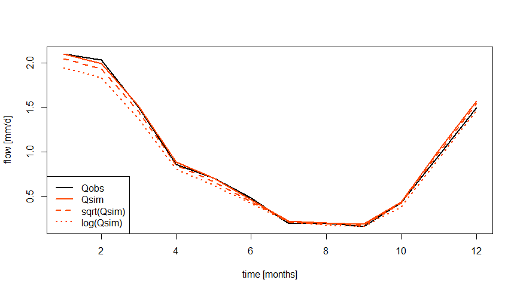

```r
# Combination of simulated streamflow
tab_sim_trsf <- data.frame(Date       = cal_raw$OutputsModel$DatesR,
                           QSIM_rawQ  = cal_raw$OutputsModel$Qsim,
                           QSIM_sqrtQ = cal_sqrt$OutputsModel$Qsim,
                           QSIM_logQ  = cal_log$OutputsModel$Qsim)
tab_sim_trsf <- merge(x = ts_obs[, c("Date", "Qmmd")],
                      y = tab_sim_trsf,
                      by = "Date",
                      all.y = TRUE)

# Computation of regime streamflow
tab_sim_reg <- SeriesAggreg(tab_sim_trsf,
                            Format = "%m",
                            ConvertFun = rep("mean", ncol(tab_sim_trsf) - 1))

# Graphical comparison between simulated and observed streamflow regimes
col_trsf <- c("black", rep("orangered", 3))
lty_trsf <- c(1, 1:3)
matplot(y = tab_sim_reg[, -1],
        xlab = "time [months]", ylab = "flow [mm/d]",
        type = "l", lty = lty_trsf, lwd = 2, col = col_trsf)
legend("bottomleft",
       legend = c("Qobs", "Qsim", "sqrt(Qsim)", "log(Qsim)"),
       lty = lty_trsf, lwd = 2, col = col_trsf,
       bg = "white")
```

## Impact of objective functions

Similarly to the use of different streamflow transformations during model calibration, the **airGRteaching** `CalGR()` function allows to test several objective functions such as NSE or KGE. The following commands and figure show how to calibrate GR4J parameters considering two objective functions, and to compare the different simulations on a specific period.

```r
# Calibration using NSE score on Q
cal_nse <- CalGR(PrepGR  = prep,
                 CalCrit = "NSE",
                 transfo = "",
                 WupPer  = c("1999-01-01", "2001-12-31"),
                 CalPer  = c("2002-01-01", "2016-12-31"))
```

```
## Grid-Screening in progress (0% 20% 40% 60% 80% 100%)
##   Screening completed (81 runs)
##       Param =  432.681,   -0.020,   83.096,    2.384
##       Crit. NSE[Q]       = 0.7414
## Steepest-descent local search in progress
##   Calibration completed (27 iterations, 281 runs)
##       Param =  237.460,   -0.746,   64.072,    5.165
##       Crit. NSE[Q]       = 0.9063
```

```r
# Calibration using KGE score on Q
cal_kge <- CalGR(PrepGR  = prep,
                 CalCrit = "KGE",
                 transfo = "",
                 WupPer  = c("1999-01-01", "2001-12-31"),
                 CalPer  = c("2002-01-01", "2016-12-31"))
```

```
## Grid-Screening in progress (0% 20% 40% 60% 80% 100%)
##   Screening completed (81 runs)
##       Param =  247.151,   -0.649,   83.096,    2.384
##       Crit. KGE[Q]       = 0.8393
## Steepest-descent local search in progress
##   Calibration completed (29 iterations, 297 runs)
##       Param =  206.888,   -0.751,   49.328,    5.360
##       Crit. KGE[Q]       = 0.9474
```

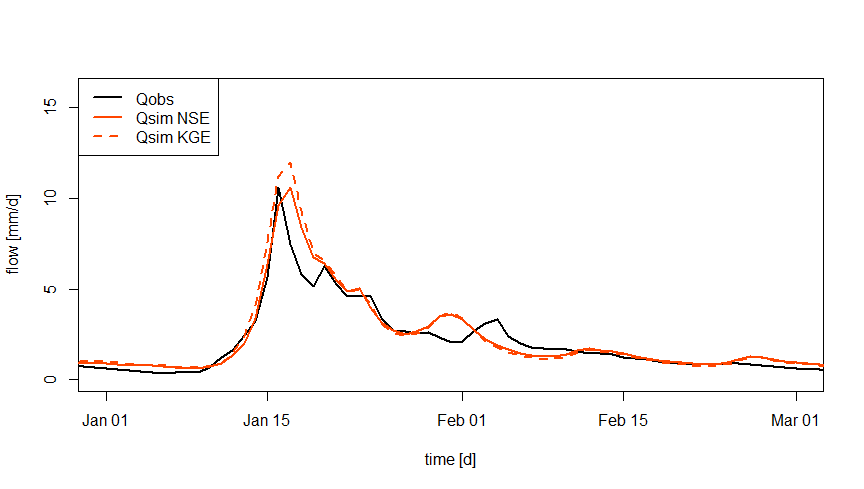

```r
# Combination of observed and simulated streamflow
tab_crit <- data.frame(Date     = as.POSIXct(cal_nse$OutputsModel$DatesR),
                       Qobs     = cal_nse$Qobs,
                       Qsim_nse = cal_nse$OutputsModel$Qsim,
                       Qsim_kge = cal_kge$OutputsModel$Qsim)

# Graphical comparison
col_crit <- c("black", rep("orangered", 2))
lty_crit <- c(1, 1:2)
matplot(x = tab_crit$Date, y = tab_crit[, -1],
        xlab = "time [d]", ylab = "flow [mm/d]",
        type = "l", lty = lty_crit, lwd = 2, col = col_crit,
        xlim = as.POSIXct(x = c("2004-01-01", "2004-03-01"), tz = "UTC"))
legend("topleft",
       legend = c("Qobs", "Qsim NSE", "Qsim KGE"),
       lty = lty_crit, lwd = 2, col = col_crit,
       bg = "white")
```

# Model evaluation and robustness

## Split-sample test

```r
# Calibration and evaluation sub-periods
per1_wup <- c("1999-01-01", "2001-12-31")
per1_sim <- c("2002-01-01", "2008-12-31")
per2_wup <- c("2009-01-01", "2011-12-31")
per2_sim <- c("2012-01-01", "2018-12-31")

# Calibration on per1 and per2
cal_per1 <- CalGR(PrepGR  = prep,
                  CalCrit = "KGE",
                  transfo = "",
                  WupPer  = per1_wup,
                  CalPer  = per1_sim,
                  verbose = TRUE)
```

```
## Grid-Screening in progress (0% 20% 40% 60% 80% 100%)
##   Screening completed (81 runs)
##       Param =  247.151,   -0.649,   83.096,    2.384
##       Crit. KGE[Q]       = 0.8234
## Steepest-descent local search in progress
##   Calibration completed (64 iterations, 603 runs)
##       Param =  218.333,   -0.929,   46.810,    5.289
##       Crit. KGE[Q]       = 0.9504
```

```r
cal_per2 <- CalGR(PrepGR  = prep,
                  CalCrit = "KGE",
                  transfo = "",
                  WupPer  = per2_wup,
                  CalPer  = per2_sim,
                  verbose = TRUE)
```

```
## Grid-Screening in progress (0% 20% 40% 60% 80% 100%)
##   Screening completed (81 runs)
##       Param =  169.017,   -0.649,   83.096,    2.384
##       Crit. KGE[Q]       = 0.8673
## Steepest-descent local search in progress
##   Calibration completed (47 iterations, 458 runs)
##       Param =  195.825,   -0.531,   62.223,    5.361
##       Crit. KGE[Q]       = 0.9579
```

```r
# Get parameter values at the end of the calibration step
param_per1 <- GetParam(cal_per1)
param_per2 <- GetParam(cal_per2)

# Get criteria values at the end of the calibration step
crit_cal_per1 <- GetCrit(cal_per1)
crit_cal_per2 <- GetCrit(cal_per2)

# Evaluation over per1 and per2
eva_per1 <- SimGR(PrepGR  = prep,
                  Param   = param_per2,
                  WupPer  = per1_wup,
                  SimPer  = per1_sim,
                  EffCrit = "KGE",
                  verbose = TRUE)
```

```
## Crit. KGE[Q] = 0.8483
##  SubCrit. KGE[Q] cor(sim, obs, "pearson") = 0.9509
##  SubCrit. KGE[Q] sd(sim)/sd(obs)          = 1.0657
##  SubCrit. KGE[Q] mean(sim)/mean(obs)      = 1.1276
```

```r
eva_per2 <- SimGR(PrepGR  = prep,
                  Param   = param_per1,
                  WupPer  = per2_wup,
                  SimPer  = per2_sim,
                  EffCrit = "KGE",
                  verbose = TRUE)
```

```
## Crit. KGE[Q] = 0.8572
##  SubCrit. KGE[Q] cor(sim, obs, "pearson") = 0.9545
##  SubCrit. KGE[Q] sd(sim)/sd(obs)          = 0.9207
##  SubCrit. KGE[Q] mean(sim)/mean(obs)      = 0.8903
```

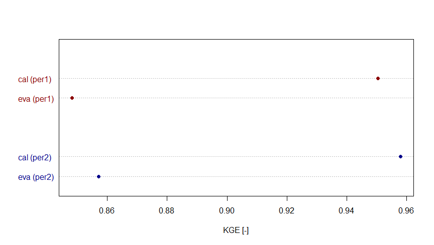

```r
# Get criteria values
crit_eva_per1 <- GetCrit(eva_per1)
crit_eva_per2 <- GetCrit(eva_per2)

# Cleveland dot plot of the criteria
dotchart(c(crit_eva_per1, crit_cal_per1, crit_eva_per2, crit_cal_per2),
         labels = c("eva (per1)", "cal (per1)", "eva (per2)", "cal (per2)"),
         groups = rep(1:2, each = 2),
         col = rep(c("darkred", "darkblue"), each = 2), pch = 19,
         xlab = "KGE [-]")
```